# COMPAS Race Analysis

Elisabeth Nesmith

3/8/2022

# Data

```python
## load in data
## In machine learning tasks, specifically with supervised learning, you have features and labels.
## The features are the descriptive attributes (they are defined as X), and the label (y) is what you're attempting to predict or forecast

X, y = fetch_compas()
print(f'There are {X.shape[0]} entries and {X.shape[1]} features')
```

```
## There are 6167 entries and 10 features
```

```python
X.head()
```

```
##                            sex  ...                   c_charge_desc
## id sex  race                    ...
## 1  Male Other             Male  ...    Aggravated Assault w/Firearm
## 3  Male African-American  Male  ...  Felony Battery w/Prior Convict
## 4  Male African-American  Male  ...           Possession of Cocaine
## 7  Male Other             Male  ...                         Battery
## 8  Male Caucasian         Male  ...       Possession Burglary Tools
##
## [5 rows x 10 columns]
```

## Filter/configure race

```python
## because our analysis is mainly focusing on how the algorithm treats white and Black people differently, we are
## dropping the rows of data where race != Caucasian or African American
X_new = X[(X.race == "Caucasian") | (X.race == "African-American")]
print(f'There are {X_new.shape[0]} entries and {X_new.shape[1]} features')
```

```
## There are 5273 entries and 10 features
```

```python
X_new.head()
```

```
##                                sex  ...                   c_charge_desc
## id sex    race                      ...
## 3  Male   African-American    Male  ...  Felony Battery w/Prior Convict
## 4  Male   African-American    Male  ...           Possession of Cocaine
## 8  Male   Caucasian           Male  ...       Possession Burglary Tools
## 10 Female Caucasian         Female  ...                         Battery
## 14 Male   Caucasian           Male  ...         Poss 3,4 MDMA (Ecstasy)
##
## [5 rows x 10 columns]
```

```python
## drop unused race categories
# list of categories to be removed
X_new["race"] = X_new["race"].cat.remove_unused_categories()
```

[output not shown]

```python
y_new = y[(y.index.get_level_values(2) == "Caucasian") | (y.index.get_level_values(2) == "African-American")]
y_new.head()
```

```
## id  sex     race
## 3   Male    African-American    Recidivated
## 4   Male    African-American    Recidivated
## 8   Male    Caucasian           Recidivated
## 10  Female  Caucasian              Survived
## 14  Male    Caucasian              Survived
## Name: two_year_recid, dtype: category
## Categories (2, object): ['Survived' < 'Recidivated']
```

```python
# Function for visualising the confusion matrix and other statistics
# https://github.com/DTrimarchi10/confusion_matrix/blob/master/cf_matrix.py

def make_confusion_matrix(cf_matrix, model):
  group_names = ["True Negative","False Positive","False Negative","True Positive"]
  group_counts = ["{0:0.0f}".format(value) for value in
                  cf_matrix.flatten()]
  group_percentages = ["{0:.2%}".format(value) for value in
                      cf_matrix.flatten()/np.sum(cf_matrix)]

  group_labels = ["{}\n".format(value) for value in group_names]
  group_counts = ["{0:0.0f}\n".format(value) for value in cf_matrix.flatten()]
  group_percentages = ["{0:.2%}".format(value) for value in cf_matrix.flatten()/np.sum(cf_matrix)]

  box_labels = [f"{v1}{v2}{v3}".strip() for v1, v2, v3 in zip(group_labels,group_counts,group_percentages)]
  box_labels = np.asarray(box_labels).reshape(cf_matrix.shape[0],cf_matrix.shape[1])


  # add more statistics
  accuracy  = np.trace(cf_matrix) / float(np.sum(cf_matrix))
  precision = cf_matrix[1,1] / sum(cf_matrix[:,1])
  recall    = cf_matrix[1,1] / sum(cf_matrix[1,:])
  f1_score  = 2*precision*recall / (precision + recall)
  stats_text = "\n\nAccuracy={:0.3f}\nPrecision={:0.3f}\nRecall={:0.3f}\nF1 Score={:0.3f}".format(
      accuracy,precision,recall,f1_score)


  categories=["Survived", "Recidivated"]
  sns.heatmap(cf_matrix,annot=box_labels,fmt="",cmap='Purples',xticklabels=categories,yticklabels=categories)

  plt.ylabel('True label')
  plt.xlabel('Predicted label' + stats_text)
  plt.title(f"Confusion matrix and statistics for the {model} model");

## defining function for displaying metrics of training and test data by sex
def metrics_per_group(y_test, y_pred):
    # y true per group
    y_test_white = y_test.loc[y_test.index.get_level_values(2) == 1]
    y_test_black = y_test.loc[y_test.index.get_level_values(2) == 0]

    # y_pred per group
    y_pred_white = y_pred[y_test.index.get_level_values(2) == 1]
    y_pred_black = y_pred[y_test.index.get_level_values(2) == 0]

    # metrics
    scores = []
    scores.append(accuracy_score(y_test, y_pred))
    scores.append(recall_score(y_test, y_pred))
    scores.append(precision_score(y_test, y_pred))

    scores.append(accuracy_score(y_test_black, y_pred_black))
    scores.append(recall_score(y_test_black, y_pred_black))
    scores.append(precision_score(y_test_black, y_pred_black))

    scores.append(accuracy_score(y_test_white, y_pred_white))
    scores.append(recall_score(y_test_white, y_pred_white))
    scores.append(precision_score(y_test_white, y_pred_white))

    attribute = ["all"]*3 + ["black"] *3 + ["white"] *3
    metric = ["accuracy", "recall", "precision"] * 3

    # dictionary of lists
    dict = {'race': attribute, 'metrics': metric, 'score': scores}

    df = pd.DataFrame(dict)

    sns.barplot(x = "metrics", y = "score", hue = "race", data = df, palette = ['#dfcd1a', '#9d0677', '#236c48'])
    plt.title("Performance metrics by groups")


def plot_fair_metrics(fair_metrics_mitigated, model):
  cols = ['statistical_parity_difference', 'equal_opportunity_difference', 'generalized_entropy']
  obj_fairness = [[0,0,1]]

  # row for objectives
  fair_metrics = pd.DataFrame(data=obj_fairness, index=['objective'], columns=cols)

  # row for baseline model
  fair_metrics.loc['Baseline Model'] = [stat_par_diff, eq_opp_diff, gen_entr_error]

  # row for mitigated bias
  fair_metrics.loc[model] = fair_metrics_mitigated


  metrics_len = len(cols)


  fig, ax = plt.subplots(figsize=(20,4), ncols=metrics_len, nrows=1)

  plt.subplots_adjust(
      left    =  0.125,
      bottom  =  0.1,
      right   =  0.9,
      top     =  0.9,
      wspace  =  .5,
      hspace  =  1.1
  )

  y_title_margin = 1.2

  plt.suptitle("Fairness metrics", y = 1.09, fontsize=20)
  sns.set(style="dark")

  cols = fair_metrics.columns.values
  obj = fair_metrics.loc['objective']
  size_rect = [0.2,0.2,0.2,0.4,0.25]
  rect = [-0.1,-0.1,-0.1,0.8,0]
  bottom = [-1,-1,-1,0,0]
  top = [1,1,1,2,1]
  bound = [[-0.1,0.1],[-0.1,0.1],[-0.1,0.1],[0.8,1.2],[0,0.25]]

  for i in range(0,metrics_len):
      plt.subplot(1, metrics_len, i+1)
      ax = sns.barplot(x=fair_metrics.index[1:len(fair_metrics)], y=fair_metrics.iloc[1:len(fair_metrics)][cols[i]])

      for j in range(0,len(fair_metrics)-1):
          a, val = ax.patches[j], fair_metrics.iloc[j+1][cols[i]]
          marg = -0.2 if val < 0 else 0.1
          ax.text(a.get_x()+a.get_width()/5, a.get_y()+a.get_height()+marg, round(val, 3), fontsize=15,color='black')

      plt.ylim(bottom[i], top[i])
      plt.setp(ax.patches, linewidth=0)
      ax.add_patch(patches.Rectangle((-5,rect[i]), 10, size_rect[i], alpha=0.3, facecolor="green", linewidth=1, linestyle='solid'))
      plt.axhline(obj[i], color='black', alpha=0.3)
      plt.title(cols[i])
      ax.set_ylabel('')
      ax.set_xlabel('')
```

```python
X_new.index = pd.MultiIndex.from_arrays(X_new.index.codes, names=X_new.index.names)
y_new.index = pd.MultiIndex.from_arrays(y_new.index.codes, names=y_new.index.names)
# 0 is African American, 2 is Caucasian
```

```python
# set caucasian equal to 1 instead of 2
X_new = X_new.rename(index={2: 1}, level='race')
X_new
```

```
##                   sex  age  ... c_charge_degree                      c_charge_desc
## id   sex race               ...
## 1    0   0       Male   34  ...               F     Felony Battery w/Prior Convict
## 2    0   0       Male   24  ...               F              Possession of Cocaine
## 4    0   1       Male   41  ...               F          Possession Burglary Tools
## 6    1   1     Female   39  ...               M                            Battery
## 7    0   1       Male   27  ...               F            Poss 3,4 MDMA (Ecstasy)
## ...               ...  ...  ...             ...                                ...
## 6165 0   0       Male   30  ...               M  Possess Cannabis/20 Grams Or Less
## 6166 0   0       Male   20  ...               F              Possession of Cocaine
## 6167 0   0       Male   23  ...               F                   Deliver Cannabis
## 6168 0   0       Male   23  ...               F      Leaving the Scene of Accident
## 6170 1   0     Female   33  ...               M      Battery on Law Enforc Officer
##
## [5273 rows x 10 columns]
```

```python
# set target class to 0/1
y_new = pd.Series(y_new.factorize(sort=True)[0], index=y_new.index)
# set caucasian equal to 1 instead of 2
y_new = y_new.rename(index={2: 1}, level='race')
```

```python
y_new
```

```
## id    sex  race
## 1     0    0       1
## 2     0    0       1
## 4     0    1       1
## 6     1    1       0
## 7     0    1       0
##                   ..
## 6165  0    0       1
## 6166  0    0       0
## 6167  0    0       0
## 6168  0    0       0
## 6170  1    0       0
## Length: 5273, dtype: int64
```

# Exploratory Data Analysis

```python
df_viz = X_new.copy()
df_viz['race'] = X_new['race'].replace({1.0: 'Caucasian', 0.0: 'African-American'})
df_viz['two_year_recid'] = y_new.replace({1:'Recidivated', 0: 'Survived'})
df_viz.index = df_viz.index.droplevel('race')

purple = '#9d0677'
green = '#30875c'
workshop_palette = [purple, green]
df_viz.head()
```

```
##            sex  age  ...                   c_charge_desc two_year_recid
## id sex               ...
## 1  0      Male   34  ...  Felony Battery w/Prior Convict    Recidivated
## 2  0      Male   24  ...           Possession of Cocaine    Recidivated
## 4  0      Male   41  ...       Possession Burglary Tools    Recidivated
## 6  1    Female   39  ...                         Battery       Survived
## 7  0      Male   27  ...         Poss 3,4 MDMA (Ecstasy)       Survived
##
## [5 rows x 11 columns]
```

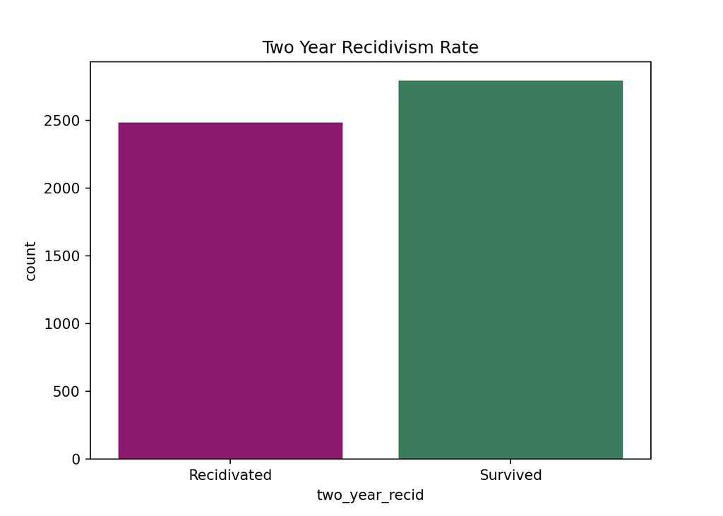

```python
# barplot of recividism
sns.countplot(x='two_year_recid', data=df_viz, palette=workshop_palette)
plt.title('Two Year Recidivism Rate')
```

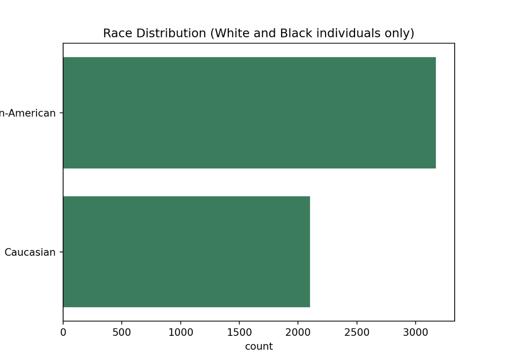

```python
# barplot of race
sns.countplot(y="race", data=df_viz, palette=["#30875c"])
plt.title('Race Distribution (White and Black individuals only)')
```

```python
# age distribution by race
ax = sns.kdeplot(x="age", hue="race", data=df_viz);
kdeline = ax.lines[0]
mean_fem = df_viz.groupby('race').age.median()[0]
xs = kdeline.get_xdata()
ys = kdeline.get_ydata()
height_fem = np.interp(mean_fem, xs, ys)
ax.vlines(mean_fem, 0, height_fem, color=purple, ls=':')

mean_m = df_viz.groupby('race').age.median()[1]
height_m = np.interp(mean_m, xs, ys)
ax.vlines(mean_m, 0, height_m, color=green, ls=':')


print(df_viz.groupby('race').age.median())
```

```
## race
## African-American    29.0
## Caucasian           35.0
## Name: age, dtype: float64
```

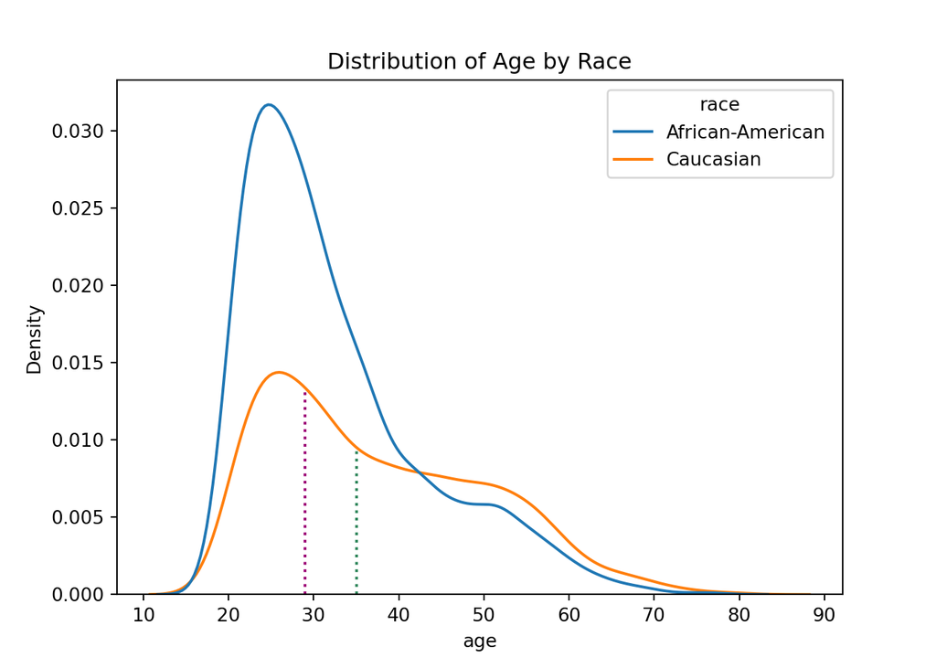

```python
plt.title('Distribution of Age by Race')
```

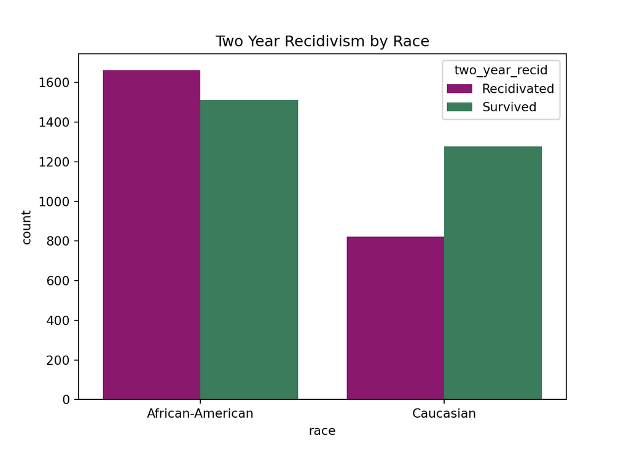

```python
# recidivism by race
by_sex = sns.countplot(x="race", hue="two_year_recid", data=df_viz, palette=workshop_palette)

plt.title('Two Year Recidivism by Race')
plt.show()
```

```python
# table of recidivism by race
pd.crosstab(index = df_viz["race"], columns = df_viz["two_year_recid"])
```

```
## two_year_recid    Recidivated  Survived
## race
## African-American         1661      1512
## Caucasian                 822      1278
```

# Baseline Metrics

```python
X_train, X_test, y_train, y_test = train_test_split(X_new, y_new, random_state=1234567)

# one-hoy encode the categorical features
data_preproc = make_column_transformer(
        (OneHotEncoder(sparse=False, handle_unknown='ignore'), X_train.dtypes == 'category'))

X_train = pd.DataFrame(data_preproc.fit_transform(X_train), index=X_train.index)
X_test = pd.DataFrame(data_preproc.transform(X_test), index=X_test.index)

# to save the information for the column names
pd.get_dummies(X_new).head()
```

```
##              age  ...  c_charge_desc_arrest case no charge
## id sex race       ...
## 1  0   0      34  ...                                    0
## 2  0   0      24  ...                                    0
## 4  0   1      41  ...                                    0
## 6  1   1      39  ...                                    0
## 7  0   1      27  ...                                    0
##
## [5 rows x 403 columns]
```

[output not shown]

[output cut: 120 more lines]

[output not shown]

```
## [Baseline] The test accuracy of the algorithm is:  61.26%
```

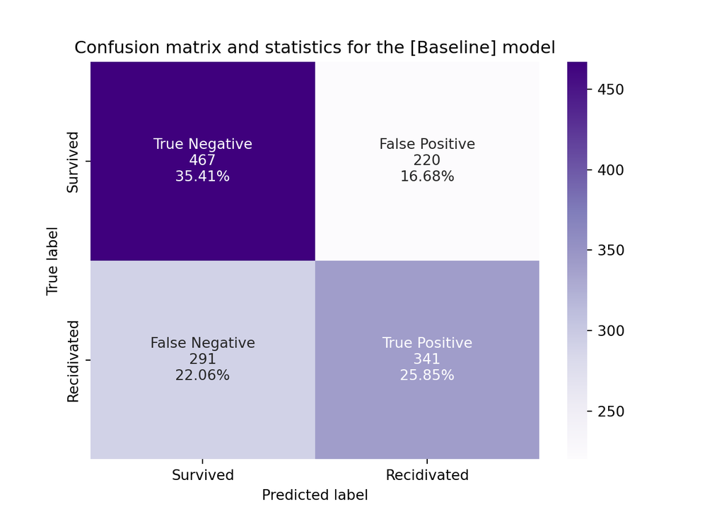

```python
##Look at 2nd column of matrix for precision
##2nd row of matrix for recall
cf_matrix = confusion_matrix(y_test, y_pred)
make_confusion_matrix(cf_matrix, "[Baseline]")
plt.show()
```

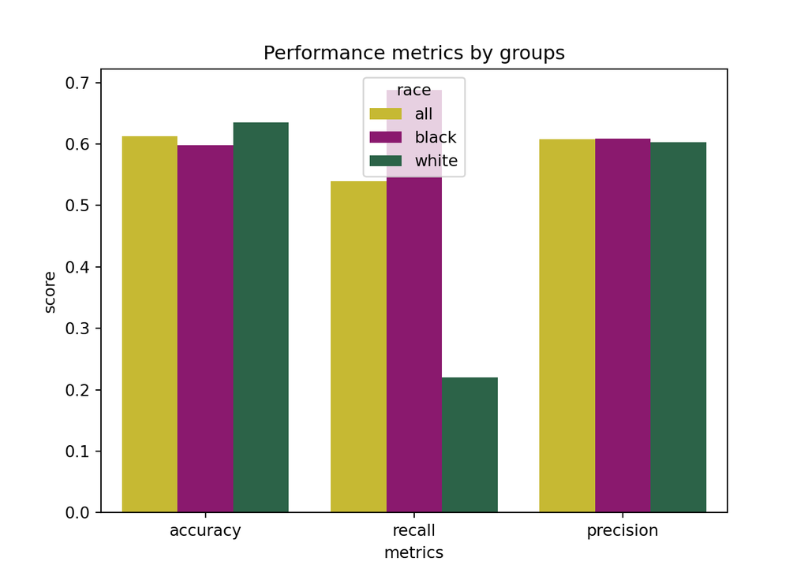

```python
metrics_per_group(y_test, y_pred)
plt.show()
```

In the Black population, the model correctly identifies 70% of people who recidivated. In the white population, the model correctly identifies 20% of people who recidivated.

### (Group fairness) Statistical Parity Difference

Computed as the difference of the rate of favorable outcomes (in this case, did not recidivate) received by the unprivileged group to the privileged group. It essentially equalizes the outcomes across the protected and non-protected groups. The ideal value of this metric is 0. Fairness for this metric is between -0.1 and 0.1. A negative value means there is higher benefit for the privileged group (in this case, white defendants).

```python
stat_par_diff = statistical_parity_difference(y_test, prot_attr='race', pos_label = 0)

print(f'[Baseline] The statistical parity difference is {stat_par_diff: .2}')
```

```
## [Baseline] The statistical parity difference is -0.14
```

```python
disp_impact_ratio = disparate_impact_ratio(y_test, y_pred, prot_attr='race', pos_label = 0)

print(f'[Baseline] The disparate impact ratio is {disp_impact_ratio: .2}')
# disparate impact ratio without y_pred attribute was 0.77
```

```
## [Baseline] The disparate impact ratio is  0.47
```

```python
avg_odds_error = average_odds_error(y_test, y_pred, prot_attr='race', pos_label = 0)

print(f'[Baseline] The average odds error is {avg_odds_error: .2}')
```

```
## [Baseline] The average odds error is  0.44
```

```python
avg_odds_diff = average_odds_difference(y_test, y_pred, prot_attr='race', pos_label = 0)

print(f'[Baseline] The average odds difference is {avg_odds_diff: .2}')
```

```
## [Baseline] The average odds difference is -0.44
```

### Generalized entropy error

Generalized entropy index is proposed as a unified individual and group fairness measure. It measures the inequality in benefit allocation for individuals. A value of 0 implies perfect fairness. Fairness is indicated by lower scores, higher scores are problematic.

```python
gen_entr_error = generalized_entropy_error(y_test, y_pred, alpha=1, pos_label = 0)

print(f'[Baseline] The generalized entropy error is {gen_entr_error: .2}')
```

```
## [Baseline] The generalized entropy error is  0.24
```

### (Group fairness) Equal Opportunity Difference

This metric is computed as the difference of true positive rates between the unprivileged and the privileged groups. The true positive rate is the ratio of true positives to the total number of actual positives for a given group. The ideal value is 0. A value of < 0 implies higher benefit for the privileged group and a value > 0 implies higher benefit for the unprivileged group. Fairness for this metric is between -0.1 and 0.1

```python
eq_opp_diff = equal_opportunity_difference(y_test, y_pred, prot_attr='race', pos_label = 0)

print(f'[Baseline] The equal opportunity difference is {eq_opp_diff: .2}')

#bt_grp_gen_entr_error = between_group_generalized_entropy_error(y_test, y_pred, alpha=1, pos_label = 0)

#print(f'[Baseline] The between group generalized entropy error is {bt_grp_gen_entr_error: .2}')

#gen_entr_index = generalized_entropy_index(x_test, alpha=0, pos_label = 0)

#print(f'[Baseline] The generalized entropy index is {gen_entr_index: .2}')

#consistency_score = consistency_score(x_test, y_test, n_neighbors=5, pos_label = 0)

#print(f'[Baseline] The consistency score is {consistency_score: .2}')
```

```
## [Baseline] The equal opportunity difference is -0.41
```

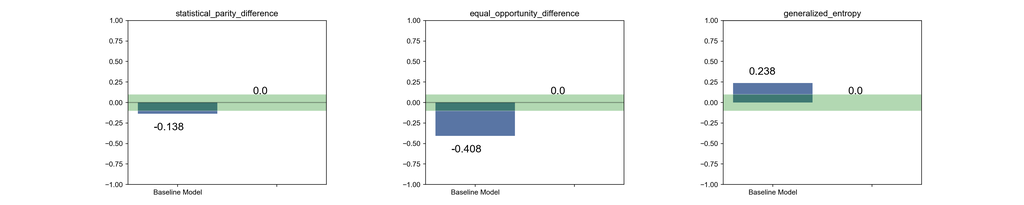

```python
plot_fair_metrics([0, 0, 0], '')
plt.show()
```

# Pre-Processing Approach

[output not shown]

[output cut: 123 more lines]

[output not shown]

```python
acc_REW = accuracy_score(y_test, y_pred_REW)
print(f'[Reweighting] The test accuracy of the algorithm is: {acc_REW: .2%}')
```

```
## [Reweighting] The test accuracy of the algorithm is:  60.96%
```

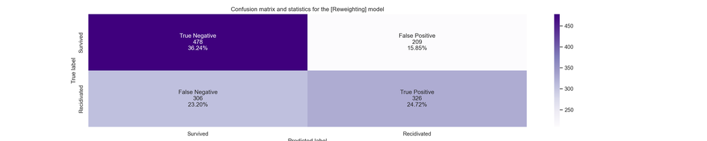

```python
cf_matrix = confusion_matrix(y_test, y_pred_REW)
make_confusion_matrix(cf_matrix, "[Reweighting]")
plt.show()
```

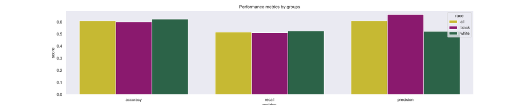

```python
metrics_per_group(y_test, y_pred_REW)
plt.show()
```

```python
stat_par_diff_RW = statistical_parity_difference(y_test, y_pred_REW, prot_attr='race', pos_label = 0)

print(f'[Reweighting] The statistical parity difference is {stat_par_diff_RW: .2}')
```

```
## [Reweighting] The statistical parity difference is -0.015
```

This is a large improvement over our baseline model, which was -0.14. It still implies a slight benefit for white individuals, but it is in the range of -0.1 and 0.1.

```python
eq_opp_diff_RW = equal_opportunity_difference(y_test, y_pred_REW, prot_attr='race', pos_label = 0)

print(f'[Reweighting] The equal opportunity difference is {eq_opp_diff_RW: .2}')
```

```
## [Reweighting] The equal opportunity difference is  0.015
```

This is also an improvement from the baseline, as it is now between -0.1 and 0.1. It also now implies a slight benefit for Black defendants.

```python
gen_entr_error_RW = generalized_entropy_error(y_test, y_pred_REW, alpha=1, pos_label = 0)

print(f'[Reweighting] The generalized entropy error is {gen_entr_error_RW: .2}')
```

```
## [Reweighting] The generalized entropy error is  0.23
```

This is only a very slight improvement from 0.24 to 0.23.

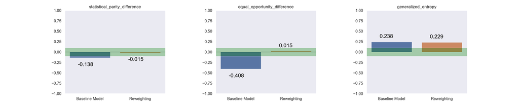

```python
plot_fair_metrics([stat_par_diff_RW, eq_opp_diff_RW, gen_entr_error_RW], 'Reweighting')
plt.show()
```

# In-Processing

```python
df_train = X_train.copy()
df_train["two_year_recid"] = y_train
df_train.rename(columns={6:'race'}, inplace=True)
df_train = df_train.reset_index(drop=True)

df_test = X_test.copy()
df_test["two_year_recid"] = y_test
df_test = df_test.reset_index(drop=True)
df_test.rename(columns={6:'race'}, inplace=True)
```

```python
train_BLD = BinaryLabelDataset(favorable_label='0',
                                unfavorable_label='1',
                                df=df_train,
                                label_names=['two_year_recid'],
                                protected_attribute_names=['race'])

test_BLD = BinaryLabelDataset(favorable_label='0',
                                unfavorable_label='1',
                                df=df_test,
                                label_names=['two_year_recid'],
                                protected_attribute_names=['race'])
```

```python
# meta = MetaFairClassifier(tau=0.8, sensitive_attr='race', type='fdr', seed=1234567)
#
# meta.fit(train_BLD)
# y_pred_META = meta.predict(test_BLD)
# y_pred_META = y_pred_META.labels.flatten()
```

```python
# acc_AD = accuracy_score(y_test, y_pred_META)
# print(f'[ Meta-Classification] The test accuracy of the algorithm is: {acc_AD: .2%}')
```

# Post-Processing

[output not shown]

[output cut: 125 more lines]

[output not shown]

```python
acc_CEO = accuracy_score(y_test, y_pred_CEO)
print(f'[Calibrated Equalized Odds] The test accuracy of the algorithm is: {acc_CEO: .2%}')
```

```
## [Calibrated Equalized Odds] The test accuracy of the algorithm is:  53.15%
```

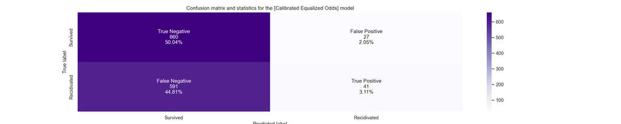

```python
cf_matrix = confusion_matrix(y_test, y_pred_CEO)
make_confusion_matrix(cf_matrix, "[Calibrated Equalized Odds]")
plt.show()
```

```python
stat_par_diff_CEO = statistical_parity_difference(y_test, y_pred_CEO, prot_attr='race', pos_label = 0)

print(f'[Calibrated Equalized Odds] The statistical parity difference is {stat_par_diff_CEO: .2}')
```

```
## [Calibrated Equalized Odds] The statistical parity difference is  0.13
```

```python
eq_opp_diff_CEO = equal_opportunity_difference(y_test, y_pred_CEO, prot_attr='race', pos_label = 0)

print(f'[Calibrated Equalized Odds] The equal opportunity difference is {eq_opp_diff_CEO: .2}')
```

```
## [Calibrated Equalized Odds] The equal opportunity difference is  0.088
```

```python
gen_entr_error_CEO = generalized_entropy_error(y_test, y_pred_CEO, alpha=1, pos_label = 0)

print(f'[Calibrated Equalized Odds] The generalized entropy error is {gen_entr_error_CEO: .2}')
```

```
## [Calibrated Equalized Odds] The generalized entropy error is  0.079
```

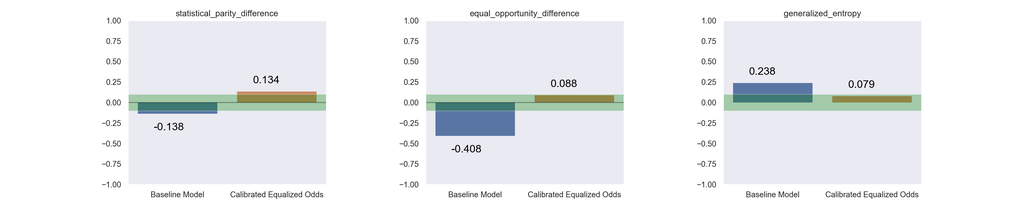

```python
plot_fair_metrics([stat_par_diff_CEO, eq_opp_diff_CEO, gen_entr_error_CEO], 'Calibrated Equalized Odds')
plt.show()
```